# Forests of Randomized Trees

```python
from sklearn.cross_validation import cross_val_score
from sklearn.datasets import make_classification
from sklearn.ensemble import RandomForestClassifier
from sklearn.ensemble import ExtraTreesClassifier
from sklearn.decomposition import PCA
import matplotlib.pyplot as plt
import numpy as np
%matplotlib inline
```

## Dataset

Simulated dataset of 1000 samples x 20 features (10 redundant features, and 8 useless features).  
Number of classes = 3

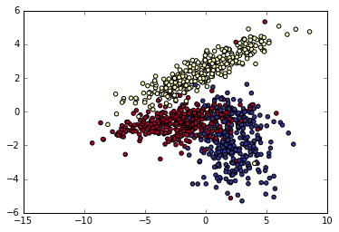

```python
X, y = make_classification(n_samples=1000, n_features=20, n_informative=2, n_redundant=10, n_classes=3,
                           n_clusters_per_class=1, random_state=1010)
X_reduced = PCA(n_components=2).fit_transform(X)
plt.scatter(X_reduced[:,0], X_reduced[:,1], marker='o', c=y, cmap=plt.cm.RdYlBu)
```

## Training & Evaluation

*Note that the below models aren't tuned/optimized and hence their performance cannot be compared.*

```python
def decision_boundary(clf):
    x_min, x_max = X_reduced[:, 0].min() - 1, X_reduced[:, 0].max() + 1
    y_min, y_max = X_reduced[:, 1].min() - 1, X_reduced[:, 1].max() + 1

    xx_fine, yy_fine = np.meshgrid(np.arange(x_min, x_max, 0.05), np.arange(y_min, y_max, 0.05))
    estimator_alpha = 1.0 / clf.n_estimators
    for tree in clf.estimators_:
        z_fine = tree.predict(np.c_[xx_fine.ravel(), yy_fine.ravel()]).reshape(xx_fine.shape)
        cs = plt.contourf(xx_fine, yy_fine, z_fine, alpha=estimator_alpha, cmap=plt.cm.RdYlBu)

    xx_coarser, yy_coarser = np.meshgrid(np.arange(x_min, x_max, 0.5), np.arange(y_min, y_max, 0.5))
    z_coarser = clf.predict(np.c_[xx_coarser.ravel(), yy_coarser.ravel()]).reshape(xx_coarser.shape)
    cs_points = plt.scatter(xx_coarser, yy_coarser, s=15, c=z_coarser, cmap=plt.cm.RdYlBu, edgecolors="none")

    for i, c in zip(range(len(np.unique(y))), "ryb"):
        idx = np.where(y == i)
        plt.scatter(X_reduced[idx, 0], X_reduced[idx, 1], c=c, cmap=plt.cm.RdYlBu)
```

```python
def eval_score(clf, name, verbose=0):
    scores = cross_val_score(clf, X, y, scoring='log_loss', cv=5,
                             verbose=verbose)
    print(name, "logloss: {0:.6f} +/- {1:.6f}".format(scores.mean(), scores.std()))
```

### Random Forest

In random forests each tree in the ensemble is built from a bootstrap sample from the training set. In addition, when splitting a node during the construction of the tree, the split that is picked is the best split among a random subset of the features. Given a training set $X = x1, ..., xn$, with responses $Y = y1, ..., yn$, prediction of a forest is the average of predictions of its trees: $$ {\hat {f}}={\frac {1}{B}}\sum _{b=1}^{B}{\hat {f}}_{b}(x') $$ where
$f_b$ is the $b$-th decision tree, and
$B$ is the number of trees or classifiers in the forest.

An upper bound for the generalization error is given by: $$PE^* \leq \bar\rho\,(1−s^2 ) / s^2,$$ where
$\bar\rho$ is the mean value of correlation between the classifiers, and
$s$ is the strength of the set of classifiers.

The generalization error approaches a limiting value as more trees are added.

```python
clf_rf = RandomForestClassifier(n_estimators=100, criterion='entropy', max_depth=22, min_samples_leaf=65,
                                max_features='sqrt', bootstrap=True, n_jobs=-1, random_state=880)
eval_score(clf_rf, 'RF')
```

```
RF logloss: -0.359672 +/- 0.025764
```

### Extra Trees

As in random forests, a random subset of candidate features is used, but instead of looking for the most discriminative thresholds, thresholds are drawn at random for each candidate feature and the best of these randomly-generated thresholds is picked as the splitting rule. Let us consider a learning sample of size $N$ $$ l_{SN} = \{(x^i, y^i): i = 1,...,N\}, $$ where each $x^i$ is an attribute vector of dimension $n$ and $y^i$ is the corresponding output value, by $I_{(i_1,...,i_n)}(x)$ the characteristic function of the hyper-interval $[x_1^{(i_1)}, x_1^{(i_1+1)}[ \, \times ... \times \, [x_n^{(i_n)}, x_n^{(i_n+1)}[$ formed from $x_j$ by taking the sample values of $j$-th attribute in increasing order. An infinite ensemble of extra trees provides an approximation in the form of: $$ \hat y(x) = \sum_{i_1=1}^N ... \sum_{i_n=0}^N I(i_1,...,i_n)(x) \sum_{X \subset \{x1...xn\}} \lambda^X_{(i_1,...,i_n)} \prod_{x_j \in X} x_j $$ $\lambda$ depends on $x_i$, $y_i$, $K$ (max features selected at each node) and $n_{min}$ (min split sample size)

```python
clf_et = ExtraTreesClassifier(n_estimators=100, criterion='gini', max_depth=10, min_samples_leaf=1,
                              max_features='sqrt', bootstrap=False, n_jobs=-1, random_state=1011)
eval_score(clf_et, 'ET')
```

```
ET logloss: -0.327050 +/- 0.100595
```

## Plot Decision Surface

### Random Forest

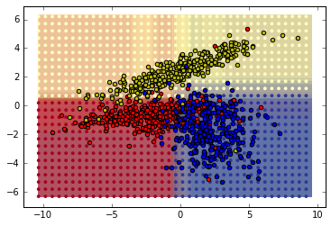

```python
clf_rf.fit(X_reduced, y)
decision_boundary(clf_rf)
```

### Extra Trees

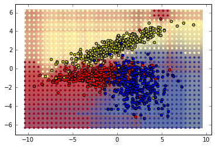

```python
clf_et.fit(X_reduced, y)
decision_boundary(clf_et)
```